# Melodic Complexity

Sam Passmore

08/06/2021

## Sequence alignment of folk song melodies reveals cross-cultural mechanisms of musical evolution

*Patrick E. Savage, Gakuto Chiba, Thomas E. Currie, Haruo Suzuki, and Quentin D. Atkinson*

# TL;DR

Using a model of `mutation rate ~ semi-tonal distance + log(note 1 frequency) * log(note 2 frequency) + (1|society)` we find that semi-tonal distance and the interaction between note frequencies are important predictors of mutation rate. We find that the likelihood of a mutation occurring decreases by 40% with each increase of semi-tone. The interaction of log note frequency is more complicated to interpret, since variables depend on each other - so this result is explained graphically below. We see that if frequency 1 increases, the mutation rate increases rapidly if frequency 2 is also increasing, but remains relatively flat if frequency 2 is low.

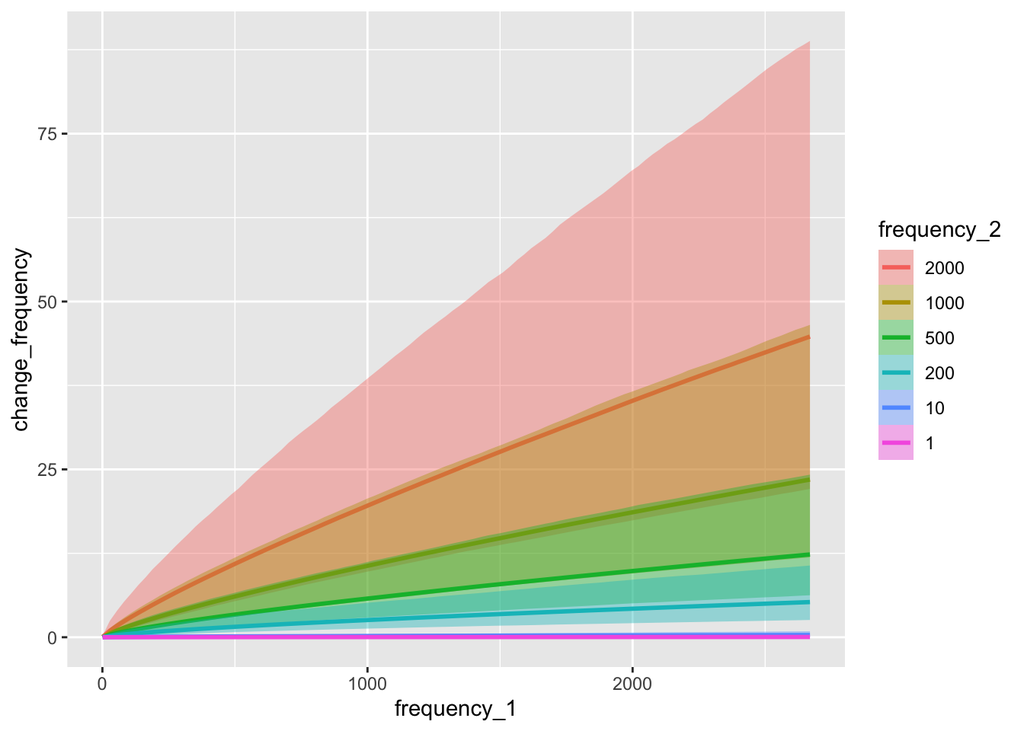

## Introduction

This document contains the modeling procedure for Savage et al. (2021). [The Pre-print is available here.](https://psyarxiv.com/5rj6y/)

Modeling was performed in response to the reviewers comments after submission to *Current Biology*, which can be summarised into the following bullet points:

- The three hypotheses presented in this paper could be tested in a single model
- There are 66 possible note mutations (ignoring directionality): the rate of mutation could be modeled using an independent variable representing the three hypotheses
- These hypotheses relate mutation frequency to:
  - Substitution distance (smaller the distance the more likely the substitution)
  - Note frequency (rarer notes are more likely to change)
  - and location of substitution. (functional notes are less likely to change)

To see the reviewer comment in full see the Reviewer Comments at the bottom of this document. What follows is an attempt to appease the reviewer.

### Data

The data for the models uses output from MelodicEvo.R ([found within the Github repository](https://github.com/pesavage/melodic-evolution)), and is created in the script reviewer_data.R (also on Github).

The data was previously displayed in table S6 & S7 (count of mutations). One matrix is for Japanese songs, the other for English songs. Semi-tonal distances between notes were provided separately. Total frequency of notes was calculated during the creation of table S6 & S7.

Currently, we do not have a variable that tests the functional location of a note change - the final point made by the reviewer.

- **Note 1 & note 2** indicate the notes being analyzed.
- **Change frequency** indicates how often changes (or mutates) between note 1 and note 2 occur (in either direction).
- **Semi-tonal distance** indicates the number of semi-tones between note 1 and note 2.
- **Society** indicates whether data is from the English or Japanese sample.
- **frequency_1 & frequency_2** indicates the overall frequency of each note in within each sample.
- **minimum_frequency** is the minimum value between frequency_1 and frequency_2.
- **total_changes** is the total number of note changes in each sample (currently unused).

There are 66 note combinations, representing all (non-directional) combinations between the 12 possible notes. For the 66 note combinations we measure their frequency of change in Japanese songs and in English songs - a total of 132 data-points. Here, we model all the data, with a random effect for society to determine whether the patterns are the same across the two groups.

Some notes never occur, meaning all mutation possibilities they occur in are zero. This was making modeling the relationship difficult, so all change frequencies that include a note which never occurs are removed. These are:

- Japanese: e g B

This removes 30 rows, resulting in a data set of 102 mutation pairs. Below is an example of the data layout.

```r
melodic_df = read.csv('results/reviewer_modeldata.csv')
kable(head(melodic_df), digits = 2)
```

| note1 | note2 | change_frequency | society | semitonal_distance | frequency_1 | frequency_2 | minimum_frequency | total_changes |
| --- | --- | --- | --- | --- | --- | --- | --- | --- |
| C | d | 0 | English | 1 | 2669 | 1 | 1 | 609 |
| C | D | 60 | English | 2 | 2669 | 1501 | 1501 | 609 |
| C | e | 8 | English | 3 | 2669 | 410 | 410 | 609 |
| C | E | 38 | English | 4 | 2669 | 1367 | 1367 | 609 |
| C | F | 14 | English | 5 | 2669 | 1285 | 1285 | 609 |
| C | g | 0 | English | 6 | 2669 | 2 | 2 | 609 |

## Data Summary

First, we look at the response, change frequency, which indicates how often changes (or mutates) between note 1 and note 2 occur (in either direction).

It is quite obvious that there are a lot of note combinations that have no changes. 29 of 66 changes do not occur in English songs, and 14 of 36 changes do not occur in Japanese songs.

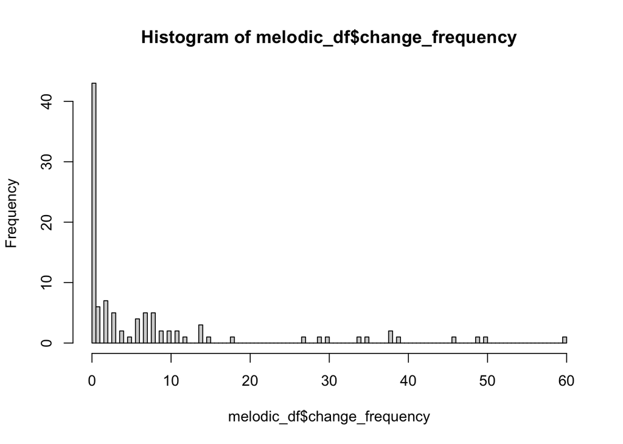

|  | English | Japanese |
| --- | --- | --- |
| Occurs | 37 | 22 |
| Does not occur | 29 | 14 |

**What changes never occur in each language?**

|  | note1 | note2 | change_frequency | society |
| --- | --- | --- | --- | --- |
| 1 | C | d | 0 | English |
| 6 | C | g | 0 | English |
| 8 | C | a | 0 | English |
| 12 | d | D | 0 | English |
| 13 | d | e | 0 | English |
| 14 | d | E | 0 | English |
| 15 | d | F | 0 | English |
| 16 | d | g | 0 | English |
| 17 | d | G | 0 | English |
| 18 | d | a | 0 | English |
| 19 | d | A | 0 | English |
| 20 | d | b | 0 | English |
| 21 | d | B | 0 | English |
| 25 | D | g | 0 | English |
| 27 | D | a | 0 | English |
| 33 | e | g | 0 | English |
| 35 | e | a | 0 | English |
| 36 | e | A | 0 | English |
| 38 | e | B | 0 | English |
| 42 | E | a | 0 | English |
| 44 | E | b | 0 | English |
| 46 | F | g | 0 | English |
| 51 | F | B | 0 | English |
| 52 | g | G | 0 | English |
| 53 | g | a | 0 | English |
| 54 | g | A | 0 | English |
| 55 | g | b | 0 | English |
| 56 | g | B | 0 | English |
| 63 | a | B | 0 | English |

|  | note1 | note2 | change_frequency | society |
| --- | --- | --- | --- | --- |
| 69 | C | E | 0 | Japanese |
| 76 | d | E | 0 | Japanese |
| 78 | d | G | 0 | Japanese |
| 79 | d | a | 0 | Japanese |
| 80 | d | A | 0 | Japanese |
| 81 | d | b | 0 | Japanese |
| 85 | D | a | 0 | Japanese |
| 88 | E | F | 0 | Japanese |
| 89 | E | G | 0 | Japanese |
| 90 | E | a | 0 | Japanese |
| 91 | E | A | 0 | Japanese |
| 92 | E | b | 0 | Japanese |
| 99 | G | b | 0 | Japanese |
| 101 | a | b | 0 | Japanese |

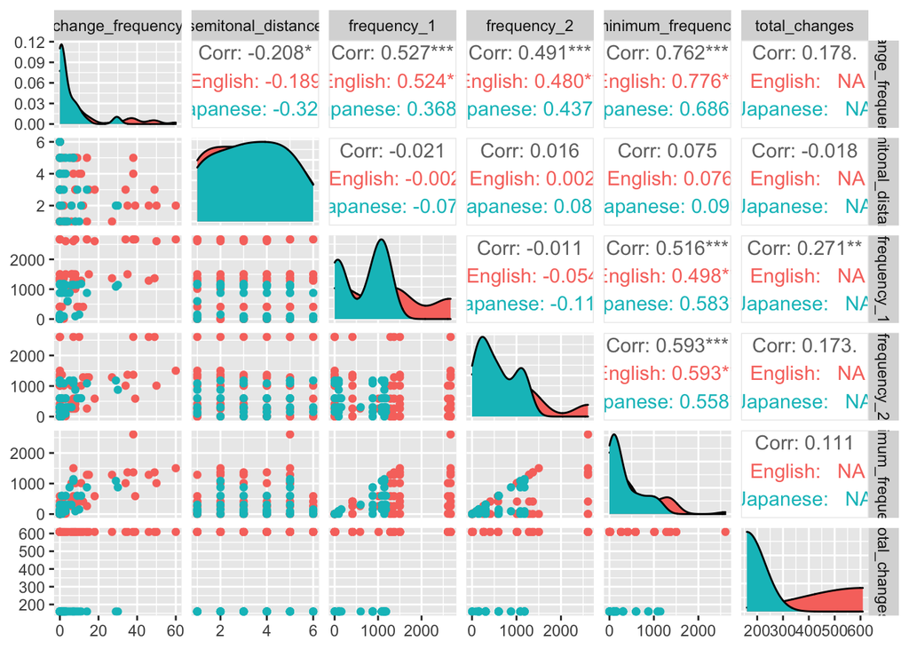

## Models

The response variable here is a count of the number of mutations occurring between any pair of notes. Three model families that are designed for count data are Binomial, Poisson, and Negative Binomial. Binomial regression is usually used when both the frequency of an outcome and number of events are known (e.g. number of heads within a series of coin tosses). Poisson is typically used in a situation where the total count is unknown (e.g. how many elephants in Africa). Negative Binomial is a comparable distribution to Poisson, and is preferred to Poisson when the count data are over-dispersed.

Here, we use negative binomial models because we have count data where the total number of mutations are unknown (i.e. all changes aren’t measured, just our sample) and because some changes occur alot, and others not at all (ie. over-dispersed).

#### Intercept-only

To see how well a negative binomial model fits the data we run an intercept only model.

```r
fit.1 <-
  brm(data = melodic_df, family = negbinomial(),
      change_frequency ~ 1,
      prior(normal(0, 10), class = Intercept),
      seed = 10, iter = 6000, warmup = 3000, chains = 2, cores = 2,
      control = list(max_treedepth = 15), sample_prior = TRUE,
      file = "results/intercept_negbin")

summary(fit.1)
```

```
##  Family: negbinomial
##   Links: mu = log; shape = identity
## Formula: change_frequency ~ 1
##    Data: melodic_df (Number of observations: 102)
## Samples: 2 chains, each with iter = 6000; warmup = 3000; thin = 1;
##          total post-warmup samples = 6000
##
## Population-Level Effects:
##           Estimate Est.Error l-95% CI u-95% CI Rhat Bulk_ESS Tail_ESS
## Intercept     2.04      0.20     1.66     2.44 1.00     4007     3262
##
## Family Specific Parameters:
##       Estimate Est.Error l-95% CI u-95% CI Rhat Bulk_ESS Tail_ESS
## shape     0.27      0.05     0.19     0.37 1.00     3985     3406
##
## Samples were drawn using sampling(NUTS). For each parameter, Bulk_ESS
## and Tail_ESS are effective sample size measures, and Rhat is the potential
## scale reduction factor on split chains (at convergence, Rhat = 1).
```

```r
fit.1 = add_criterion(fit.1, "loo")
```

Predicting mutation changes performs quite well only based on the negative-binomial assumption.

The mean number of transitions over the entire set is 7.54, and the estimate is 7.66. However, as we can see from the predictive plot below, the model is failing in some areas, in particular why no changes would occur. I will use the plot throughout to understand the model fit, so it is worth explaining in a bit more detail here. The dark blue line ‘y’ is how the data in the response variable - mutation rate - is distributed. Each light blue line are different predictions based on the model we have built. There are 100 predicted models drawn from the Bayesian posterior. Generating predictions based on the Bayesian model gives us an idea of how well the model fits the data, and doing this multiple times gives a measure of how much error there is within the predictions. In this plot, the y-axis is very long because there is high variability in the estimates for y = 0 drawn from our model posterior.

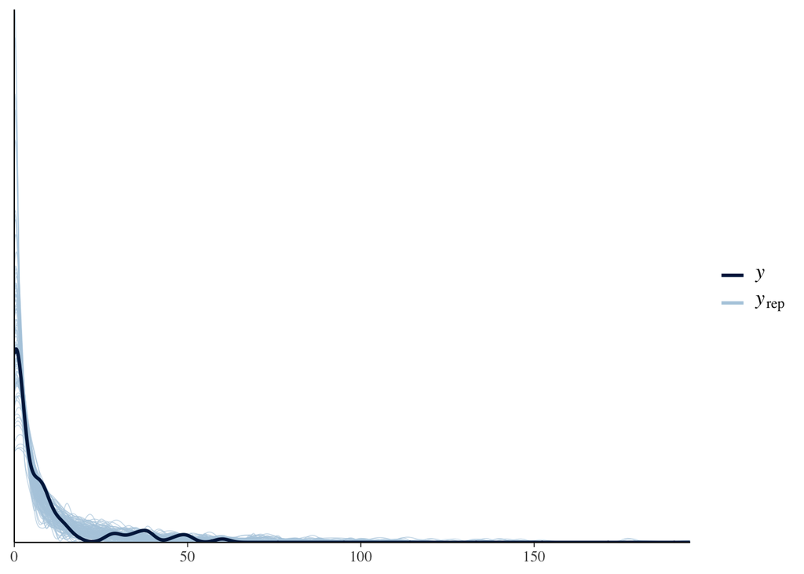

#### Independent variable models

First, we determine whether there is significant difference between the English and Japanese samples in our data. None of the hypotheses focus on this group comparison, but we want to know if it is worth pooling the data together for all models, or it is better to keep them separate.

Following that, we model the relationship between mutation rate and semi-tonal distance, and then model the relationship between mutation rate and frequency of the notes in the total sample - which align with the hypotheses listed at the top.

##### Society

```r
fit.2 =
  brm(data = melodic_df, family = negbinomial(),
      change_frequency ~ 1 + society,
      prior(normal(0, 10), class = Intercept),
      seed = 10, iter = 6000, warmup = 3000, chains = 2, cores = 2,
      control = list(max_treedepth = 15, adapt_delta = 0.99),
      sample_prior = TRUE, file = "results/society_negbinom")

summary(fit.2)
```

```
##  Family: negbinomial
##   Links: mu = log; shape = identity
## Formula: change_frequency ~ 1 + society
##    Data: melodic_df (Number of observations: 102)
## Samples: 2 chains, each with iter = 6000; warmup = 3000; thin = 1;
##          total post-warmup samples = 6000
##
## Population-Level Effects:
##                 Estimate Est.Error l-95% CI u-95% CI Rhat Bulk_ESS Tail_ESS
## Intercept           2.25      0.25     1.79     2.76 1.00     4699     3313
## societyJapanese    -0.70      0.43    -1.51     0.16 1.00     4137     2970
##
## Family Specific Parameters:
##       Estimate Est.Error l-95% CI u-95% CI Rhat Bulk_ESS Tail_ESS
## shape     0.27      0.05     0.19     0.38 1.00     4127     3405
##
## Samples were drawn using sampling(NUTS). For each parameter, Bulk_ESS
## and Tail_ESS are effective sample size measures, and Rhat is the potential
## scale reduction factor on split chains (at convergence, Rhat = 1).
```

Again the model performs pretty well at determining the general effects of the groups. The figure about shows estimates for the mean number of mutations within each group. The true values are in the table below, with predicted values in the graph.

| society | mean(change_frequency) |
| --- | --- |
| English | 9.23 |
| Japanese | 4.44 |

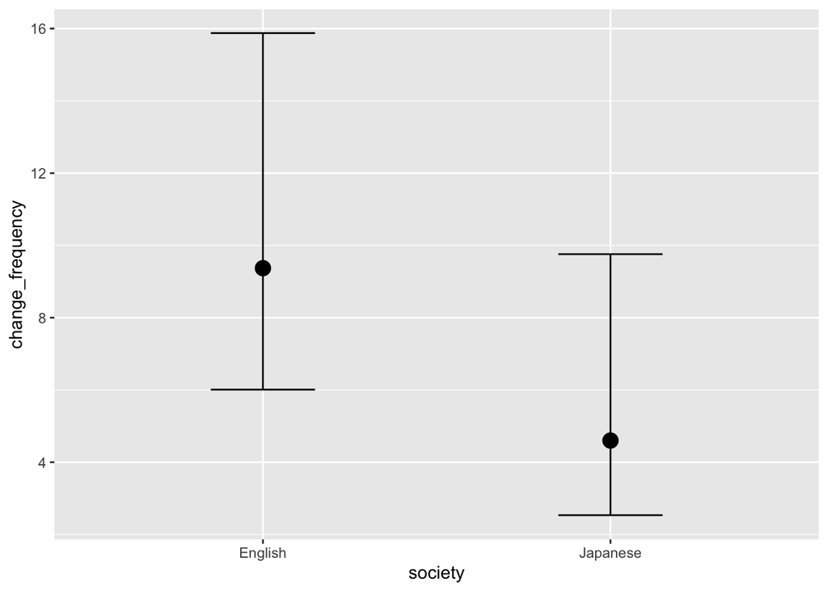

#### Semi-tonal distance

The paper proposes that when a mutation occurs it is more likely to be a small semi-tonal distances. Here we test that relationship in a bi-variate model, with a random effect for society. Here we see that for each increase in semi-tonal distance increases, the probability of a mutation decreases by ~41% (result under `fixed(coef) %>% inv_logit_scaled`). However, there is quite a lot of error surrounding this estimate.

```r
fit.3 <-
  brm(data = melodic_df, family = negbinomial(),
      change_frequency ~ semitonal_distance + (1|society),
      c(prior(normal(0, 4), class = Intercept),
        prior(normal(0, 2), class = b),
        prior(cauchy(0, 0.5), class = sd)),
      seed = 10, iter = 10000, warmup = 5000, chains = 2, cores = 2,
      control = list(max_treedepth = 15, adapt_delta = 0.99),
      sample_prior = TRUE,
      file = "results/semitonaldistance_negbin")

summary(fit.3)
```

```
##  Family: negbinomial
##   Links: mu = log; shape = identity
## Formula: change_frequency ~ semitonal_distance + (1 | society)
##    Data: melodic_df (Number of observations: 102)
## Samples: 2 chains, each with iter = 10000; warmup = 5000; thin = 1;
##          total post-warmup samples = 10000
##
## Group-Level Effects:
## ~society (Number of levels: 2)
##               Estimate Est.Error l-95% CI u-95% CI Rhat Bulk_ESS Tail_ESS
## sd(Intercept)     0.62      0.68     0.02     2.44 1.00     2565     2777
##
## Population-Level Effects:
##                    Estimate Est.Error l-95% CI u-95% CI Rhat Bulk_ESS Tail_ESS
## Intercept              2.94      0.74     1.38     4.37 1.00     3953     2888
## semitonal_distance    -0.34      0.14    -0.61    -0.07 1.00     6422     5709
##
## Family Specific Parameters:
##       Estimate Est.Error l-95% CI u-95% CI Rhat Bulk_ESS Tail_ESS
## shape     0.29      0.05     0.20     0.40 1.00     7004     6178
##
## Samples were drawn using sampling(NUTS). For each parameter, Bulk_ESS
## and Tail_ESS are effective sample size measures, and Rhat is the potential
## scale reduction factor on split chains (at convergence, Rhat = 1).
```

```r
fit.3 = add_criterion(fit.3, "loo")
```

|  | Estimate | Est.Error | Q2.5 | Q97.5 |
| --- | --- | --- | --- | --- |
| Intercept | 0.95 | 0.68 | 0.80 | 0.99 |
| semitonal_distance | 0.42 | 0.54 | 0.35 | 0.48 |

|  | elpd_diff | se_diff | elpd_loo | se_elpd_loo | p_loo | se_p_loo | looic | se_looic |
| --- | --- | --- | --- | --- | --- | --- | --- | --- |
| fit.3 | 0.00 | 0.00 | -276.28 | 18.53 | 3.01 | 0.52 | 552.56 | 37.07 |
| fit.1 | -2.53 | 2.14 | -278.81 | 18.70 | 1.79 | 0.18 | 557.62 | 37.40 |

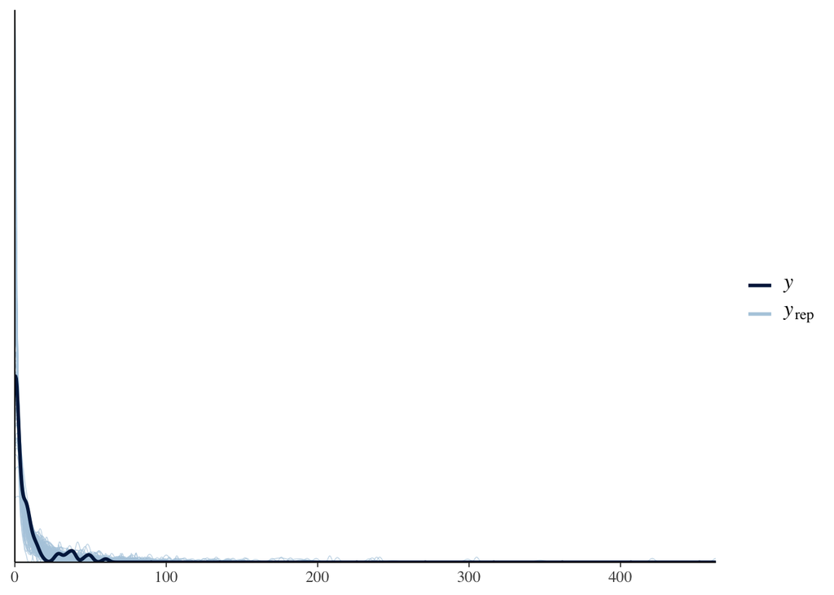

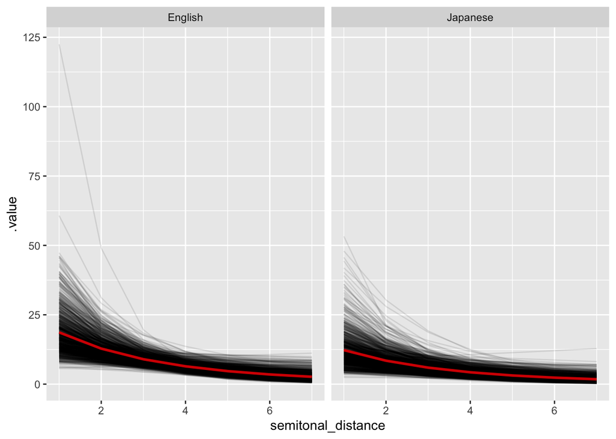

#### Frequency

Here, we look at the effect of frequency on the rate of mutation response variable. There are 3 proposed ways to look at frequency:

- Model the frequency of each note separately and as an interaction
  - This will assumes a non-linear relationship between note frequency and mutation
- Include a variable which is the product of each notes frequency
  - This is similar to above, but ignores the independent effects of frequency
- Include a variable containing the minimum value of frequency
  - This assumes the mutation rate is only effected by a bottleneck caused by the least frequent note.

We model raw frequency counts on the log scale because of the skewed distribution in note frequency (some notes occur a lot and some not often). In the case of the interaction variable, frequency values are logged and then multiplied.

```r
fit.4.1 = brm(data = melodic_df, family = negbinomial(),
                change_frequency ~ log(frequency_1) * log(frequency_2) + (1|society),
                c(prior(normal(0, 4), class = Intercept),
                  prior(cauchy(0, 2), class = b),
                  prior(cauchy(0, 0.5), class = sd)),
                seed = 10, iter = 10000, warmup = 5000, chains = 2, cores = 2,
                control = list(max_treedepth = 15, adapt_delta = 0.99),
                sample_prior = TRUE, file = "results/frequencyint_negbin",
                init_r = 0)

fit.4.2 = brm(data = melodic_df, family = negbinomial(),
              change_frequency ~ log_frequencyinteraction + (1|society),
              c(prior(cauchy(0, 0.5), class = Intercept),
                prior(cauchy(0, 0.5), class = b),
                prior(cauchy(0, 0.5), class = sd)),
              seed = 10, iter = 20000, warmup = 15000, chains = 2, cores = 2,
              control = list(max_treedepth = 15, adapt_delta = 0.99),
              sample_prior = TRUE, file = "results/frequencyint2_negbin")

fit.4.3 = brm(data = melodic_df, family = negbinomial(),
              change_frequency ~ minimum_frequency + (1|society),
              c(prior(cauchy(0, 4), class = Intercept),
                prior(cauchy(0, 2), class = b),
                prior(cauchy(0, 0.5), class = sd)),
              seed = 10, iter = 10000, warmup = 5000, chains = 2, cores = 2,
              control = list(max_treedepth = 15, adapt_delta = 0.99),
              sample_prior = TRUE, file = "results/minfrequency_negbin")

fit.4.1 = add_criterion(fit.4.1, "loo")
fit.4.2 = add_criterion(fit.4.2, "loo")
fit.4.3 = add_criterion(fit.4.3, "loo")

kable(loo_compare(fit.4.1, fit.4.2, fit.4.3),digits = 2)
```

|  | elpd_diff | se_diff | elpd_loo | se_elpd_loo | p_loo | se_p_loo | looic | se_looic |
| --- | --- | --- | --- | --- | --- | --- | --- | --- |
| fit.4.2 | 0.00 | 0.00 | -218.70 | 17.03 | 3.80 | 0.73 | 437.40 | 34.07 |
| fit.4.1 | -0.95 | 0.75 | -219.65 | 17.03 | 5.38 | 1.07 | 439.31 | 34.06 |
| fit.4.3 | -29.61 | 6.75 | -248.31 | 18.03 | 3.41 | 0.67 | 496.63 | 36.06 |

Comparing these three models to each other we find that only using the minimum frequency value for both notes performs considerably worse than models that include frequency for both notes. This suggests an interactive relationship is important. There is only a negligible difference between the model containing both frequency values and the interaction variable. These two approaches are very mathematically similar so this is not particularly surprising. For future reference I will call the model in the form of `log(frequency_1) * log(frequency_2)` as the full interaction model, and the model of the form `logfrequency_interaction` as the interaction only model.

Although the full interaction model performs slightly worse, my opinion is that we should prefer it. The full interaction model is more explicit about the relationship between variables, it is also more common to include both main and interaction effects, and the model requires less stringent priors to obtain convergence. Having said that, a philosophical point is that in the full interaction model, no individual effect is significant, while in the interaction only model, the interaction effect is (what might conventionally be called) significant. This point then becomes a more philosophical debate around how we think about statistics in science which I will omit from this report.

Notably the model still doesn’t deal with zero mutation values well.

```r
summary(fit.4.1)
```

```
##  Family: negbinomial
##   Links: mu = log; shape = identity
## Formula: change_frequency ~ log(frequency_1) * log(frequency_2) + (1 | society)
##    Data: melodic_df (Number of observations: 102)
## Samples: 2 chains, each with iter = 10000; warmup = 5000; thin = 1;
##          total post-warmup samples = 10000
##
## Group-Level Effects:
## ~society (Number of levels: 2)
##               Estimate Est.Error l-95% CI u-95% CI Rhat Bulk_ESS Tail_ESS
## sd(Intercept)     0.32      0.47     0.01     1.37 1.00     3027     3097
##
## Population-Level Effects:
##                               Estimate Est.Error l-95% CI u-95% CI Rhat
## Intercept                        -7.73      3.90   -16.31    -1.17 1.00
## logfrequency_1                    0.68      0.54    -0.24     1.85 1.00
## logfrequency_2                    0.73      0.58    -0.26     1.97 1.00
## logfrequency_1:logfrequency_2     0.01      0.08    -0.16     0.15 1.00
##                               Bulk_ESS Tail_ESS
## Intercept                         2462     2881
## logfrequency_1                    2468     2771
## logfrequency_2                    2514     2980
## logfrequency_1:logfrequency_2     2490     2743
##
## Family Specific Parameters:
##       Estimate Est.Error l-95% CI u-95% CI Rhat Bulk_ESS Tail_ESS
## shape     1.74      0.46     1.02     2.80 1.00     6310     6048
##
## Samples were drawn using sampling(NUTS). For each parameter, Bulk_ESS
## and Tail_ESS are effective sample size measures, and Rhat is the potential
## scale reduction factor on split chains (at convergence, Rhat = 1).
```

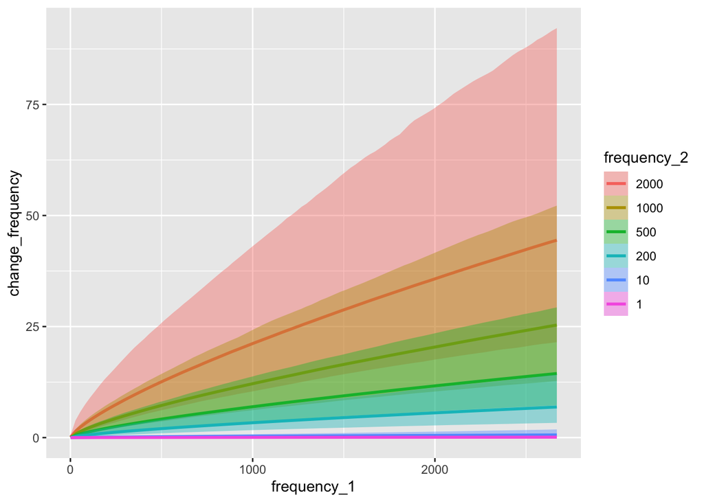

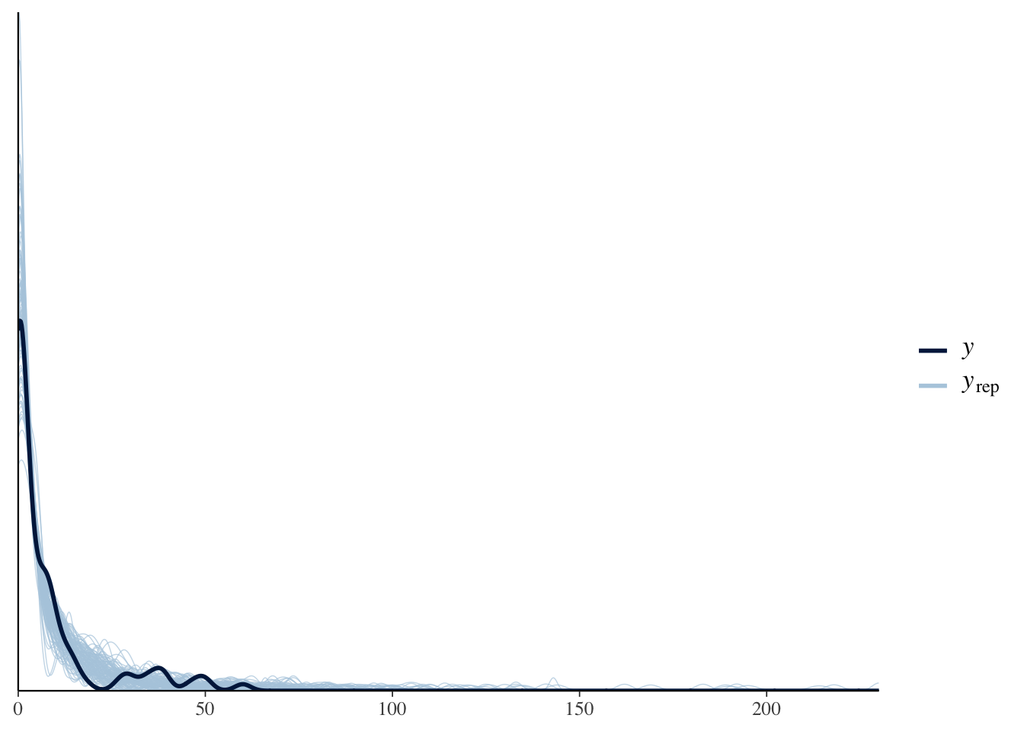

#### Complete Model

```r
fit.5 = brm(data = melodic_df, family = negbinomial(),
              change_frequency ~ semitonal_distance +
              log(frequency_1) * log(frequency_2) + (1|society),
              c(prior(normal(0, 4), class = Intercept),
                prior(cauchy(0, 2), class = b),
                prior(cauchy(0, 0.5), class = sd)),
              seed = 10, iter = 20000, warmup = 15000, chains = 2, cores = 2,
              control = list(max_treedepth = 15, adapt_delta = 0.99),
              sample_prior = TRUE, file = "results/full_negbin",
              init_r = 0)

summary(fit.5)
```

```
##  Family: negbinomial
##   Links: mu = log; shape = identity
## Formula: change_frequency ~ semitonal_distance + log(frequency_1) * log(frequency_2) + (1 | society)
##    Data: melodic_df (Number of observations: 102)
## Samples: 2 chains, each with iter = 20000; warmup = 15000; thin = 1;
##          total post-warmup samples = 10000
##
## Group-Level Effects:
## ~society (Number of levels: 2)
##               Estimate Est.Error l-95% CI u-95% CI Rhat Bulk_ESS Tail_ESS
## sd(Intercept)     0.30      0.46     0.01     1.40 1.00     3201     4292
##
## Population-Level Effects:
##                               Estimate Est.Error l-95% CI u-95% CI Rhat
## Intercept                        -5.55      3.66   -13.38     0.67 1.00
## semitonal_distance               -0.41      0.06    -0.52    -0.31 1.00
## logfrequency_1                    0.46      0.50    -0.41     1.53 1.00
## logfrequency_2                    0.53      0.54    -0.38     1.67 1.00
## logfrequency_1:logfrequency_2     0.05      0.07    -0.11     0.18 1.00
##                               Bulk_ESS Tail_ESS
## Intercept                         3359     3856
## semitonal_distance                7118     5848
## logfrequency_1                    3423     3884
## logfrequency_2                    3417     3886
## logfrequency_1:logfrequency_2     3411     3821
##
## Family Specific Parameters:
##       Estimate Est.Error l-95% CI u-95% CI Rhat Bulk_ESS Tail_ESS
## shape     5.27      2.10     2.50    10.49 1.00     6748     5079
##
## Samples were drawn using sampling(NUTS). For each parameter, Bulk_ESS
## and Tail_ESS are effective sample size measures, and Rhat is the potential
## scale reduction factor on split chains (at convergence, Rhat = 1).
```

```r
fixef(fit.5) %>% inv_logit_scaled()
```

```
##                                  Estimate Est.Error         Q2.5     Q97.5
## Intercept                     0.003888278 0.9749166 1.549479e-06 0.6614808
## semitonal_distance            0.398030854 0.5139567 3.717085e-01 0.4240244
## logfrequency_1                0.612842571 0.6233899 4.000028e-01 0.8226883
## logfrequency_2                0.630294007 0.6310935 4.054510e-01 0.8414324
## logfrequency_1:logfrequency_2 0.512632771 0.5185760 4.735518e-01 0.5445394
```

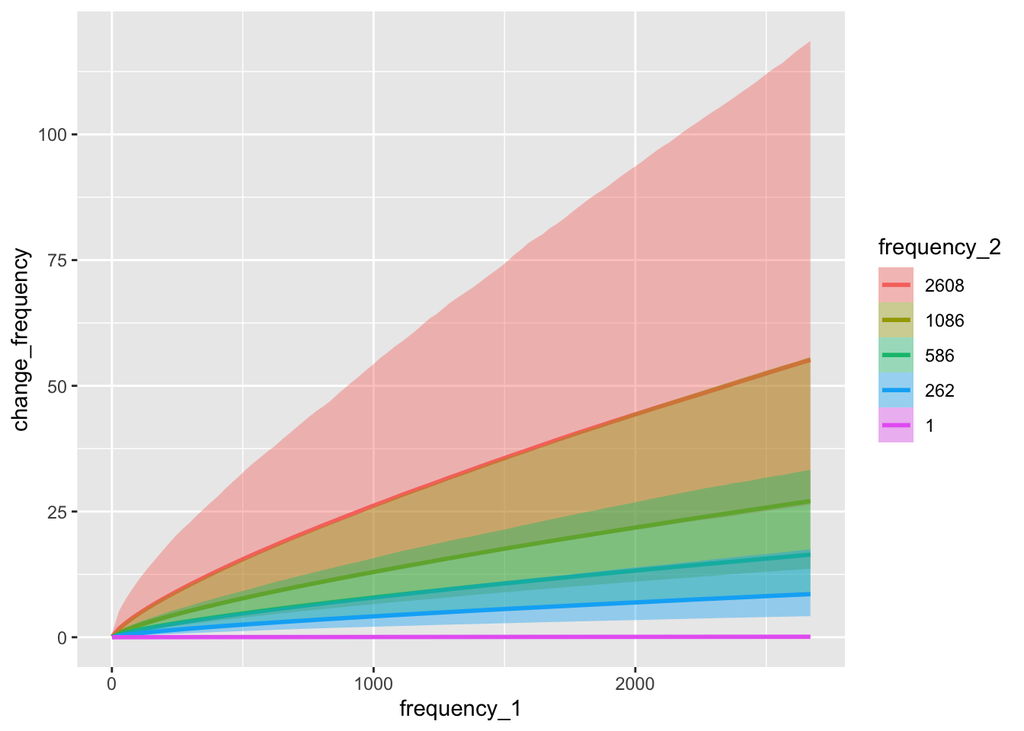

```r
conditional_effects(fit.4.1, effects = "frequency_1:frequency_2",
                    int_conditions = list(frequency_2 = quantile))
```

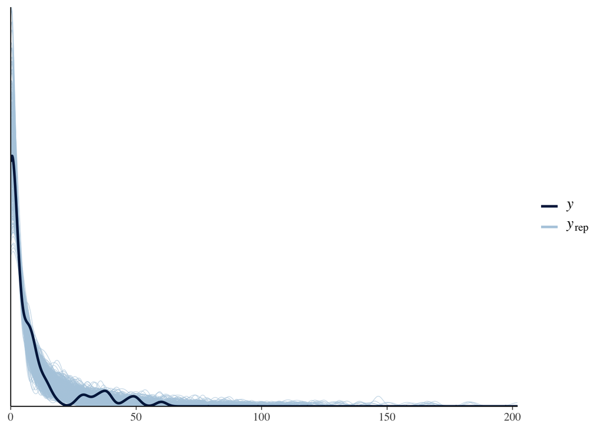

```r
pp_check(fit.5, nsamples = 500)
```

##### Model comparison

Comparing all models, the complete model (containing semi-tonal and frequency measures) is the best model by some distance. This suggests that both semitonal distance and frequency of notes are important in determining the likelihood of a mutation.

```r
fit.3 = add_criterion(fit.3, "loo")
fit.5 = add_criterion(fit.5, "loo")

loo_compare(fit.1, fit.3, fit.4.1, fit.5) %>% kable(digits = 2)
```

|  | elpd_diff | se_diff | elpd_loo | se_elpd_loo | p_loo | se_p_loo | looic | se_looic |
| --- | --- | --- | --- | --- | --- | --- | --- | --- |
| fit.5 | 0.00 | 0.00 | -197.99 | 16.98 | 7.53 | 1.90 | 395.97 | 33.95 |
| fit.4.1 | -21.67 | 7.94 | -219.65 | 17.03 | 5.38 | 1.07 | 439.31 | 34.06 |
| fit.3 | -78.29 | 10.67 | -276.28 | 18.53 | 3.01 | 0.52 | 552.56 | 37.07 |
| fit.1 | -80.82 | 10.79 | -278.81 | 18.70 | 1.79 | 0.18 | 557.62 | 37.40 |

For sake of argument, we also compare the complete model, containing the full interaction frequency model against a complete model, containing the interaction only frequency model. Again, this shows a negligble difference between the models, with a slight preference for the interaction only frequency model.

```r
fit.5.1 = brm(data = melodic_df, family = negbinomial(),
            change_frequency ~ semitonal_distance + log_frequencyinteraction + (1|society),
            c(prior(cauchy(0, 0.5), class = Intercept),
              prior(cauchy(0, 0.5), class = b),
              prior(cauchy(0, 0.5), class = sd)),
            seed = 10, iter = 20000, warmup = 15000, chains = 2, cores = 2,
            control = list(max_treedepth = 15, adapt_delta = 0.99),
            sample_prior = TRUE, file = "results/full2_negbin")

fit.5.1 = add_criterion(fit.5.1, "loo")

loo_compare(fit.5, fit.5.1) %>% kable(digits = 2)
```

|  | elpd_diff | se_diff | elpd_loo | se_elpd_loo | p_loo | se_p_loo | looic | se_looic |
| --- | --- | --- | --- | --- | --- | --- | --- | --- |
| fit.5.1 | 0.00 | 0.00 | -196.32 | 16.72 | 5.53 | 1.45 | 392.64 | 33.44 |
| fit.5 | -1.67 | 0.81 | -197.99 | 16.98 | 7.53 | 1.90 | 395.97 | 33.95 |

## Summary

- *since the dependent variable is the same, the authors will be able to estimate the relative importance of their three selective forces by examining the variance explained by each; currently the cannot.*
  - (We can address this more directly than I have so far)
- *The explanatory variables might, themselves, be correlated; my analysis would make that clear.*
  - Correlations between the two variables suggest this is unlikely. Since the effects of semi-tonal distance and frequency are relatively similar in bi-variate and multi-variate models, this is further evidence that the effects are unrelated.
- *They can search for interactions among their explanatory variables. Perhaps substitutions at functional sites are not only rare, but also tend to involve particularly small jumps.*
  - Interactions between frequency of notes were important. We do not currently have the data to test whether an interaction between functional sites and semi-tonal changes.
- *The authors will be able to get uncertainties around their point estimates*
  - We have these from the model fits, however, these will likely be overestimates. By testing this across more societies (which use this scale range), we will have better estimates.

### Reviewer comments

*"The three hypotheses: about substitution distance, note frequency dependence, and note functionality, can all be couched in exactly the same terms: substitutions requiring big jumps in musical space should be rare relative to those requiring small jumps; substitutions in common notes should be rare relative to those in rare notes; substitutions in functionally important notes should be rare relative to those in functionally unimportant notes (ornamental notes).*

*That seems clear, yet for some reason the authors have chosen to couch, and test, these hypotheses in terms of related, but different, dependent variables. The jump-dependency is tested in terms of “number of substitutions”; the frequency dependency is tested in terms of “mutability”; the functional hypothesis is tested in terms of “evolutionary rate”. But this seems to me unnecessary and opaque.*

*I think what they want to do is very simple. There are 66 possible substitutions (12^2-12)/2) forgetting about directionality. Obtain, for each corpus, the frequency of each possible subsitution oberved in the data. These frequencies are those shown in Figure 3c. Classify each possible substution in terms of their three dependent variables: distance (7 states); note frequency (continuous); and the frequency with which each subsitution is observed at a functional location. Modelling the dependent variable, the observed frequency of a given substitution, in terms of these three independent variables will, I think, give a much clearer interpretation of the result — and, unless I am greatly mistaken, show much the same effects shown in Figure 4.*

*My suggested analysis, however, has four benefits. (i) since the dependent variable is the same, the authors will be able to estimate the relative importance of their three selective forces by examining the variance explained by each; currently the cannot. (ii) The explanatory variables might, themselves, be correlated; my analysis would make that clear. (iii) They can search for interactions among their explanatory variables. Perhaps substitutions at functional sites are not only rare, but also tend to involve particularly small jumps. (iv) The authors will be able to get uncertainties around their point estimates (see below).*

*I appreciate that the authors might not wish to adopt my proposed analysis or something like it, however, if they do not they should explain clearly why they have couched their hypotheses in different terms when they seem to involve the same thing."*